# The Role of Influenza Vaccine Dose Towards Homologous and Heterologous Protection

2020-12-01 15:34:43

## Introduction

- Inoculum dose is an important determinant of infection or vaccination outcomes.
- For infection, higher dose is often associated with greater risk of infection (e.g. ID50) and more severe outcomes (e.g. LD50).
- **For vaccines**, dose is thought to impact both immunogenicity and side effects (morbidity).

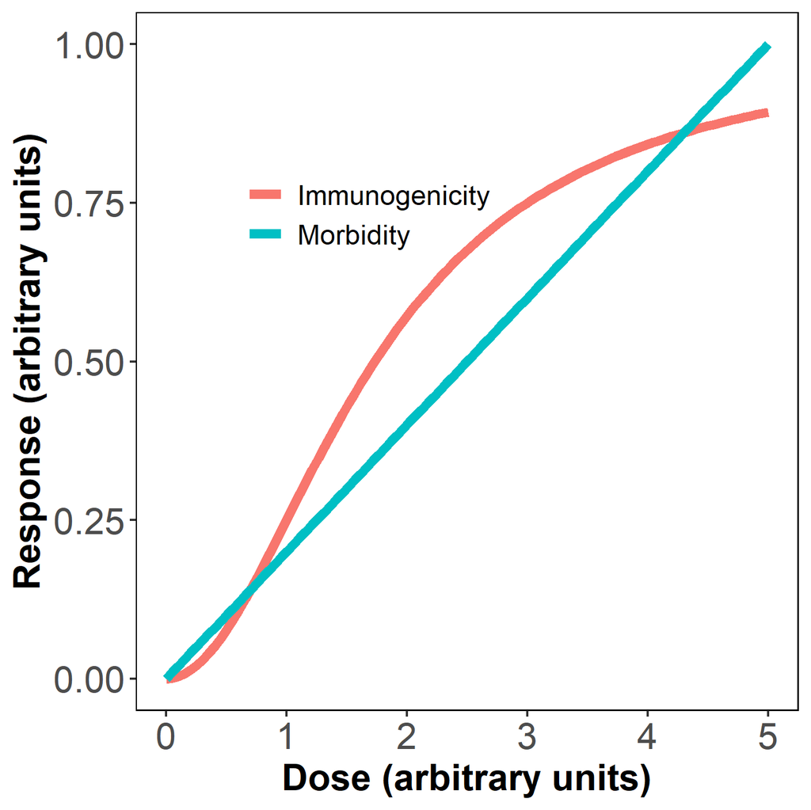

## Current approaches to dose choice

- Generally, a few (~3) doses are explored in phase I and II trials.
- Based on those data, one of the doses is chosen in a non-rigorous manner.

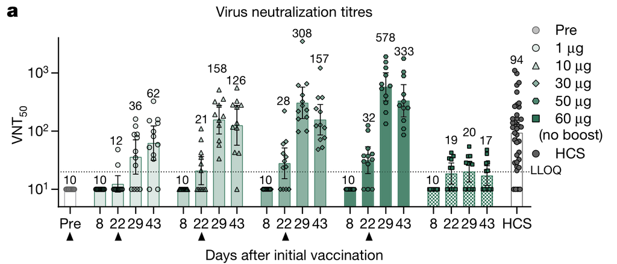

[Example of BioNTech/Pfizer COVID Vaccine](https://doi.org/10.1038/s41586-020-2814-7)

## Possible important issues

- Impact of dose on immunogenicity might not be monotone (e.g. AstraZeneca COVID vaccine).
- For a universal influenza vaccine breadth of protection is important.

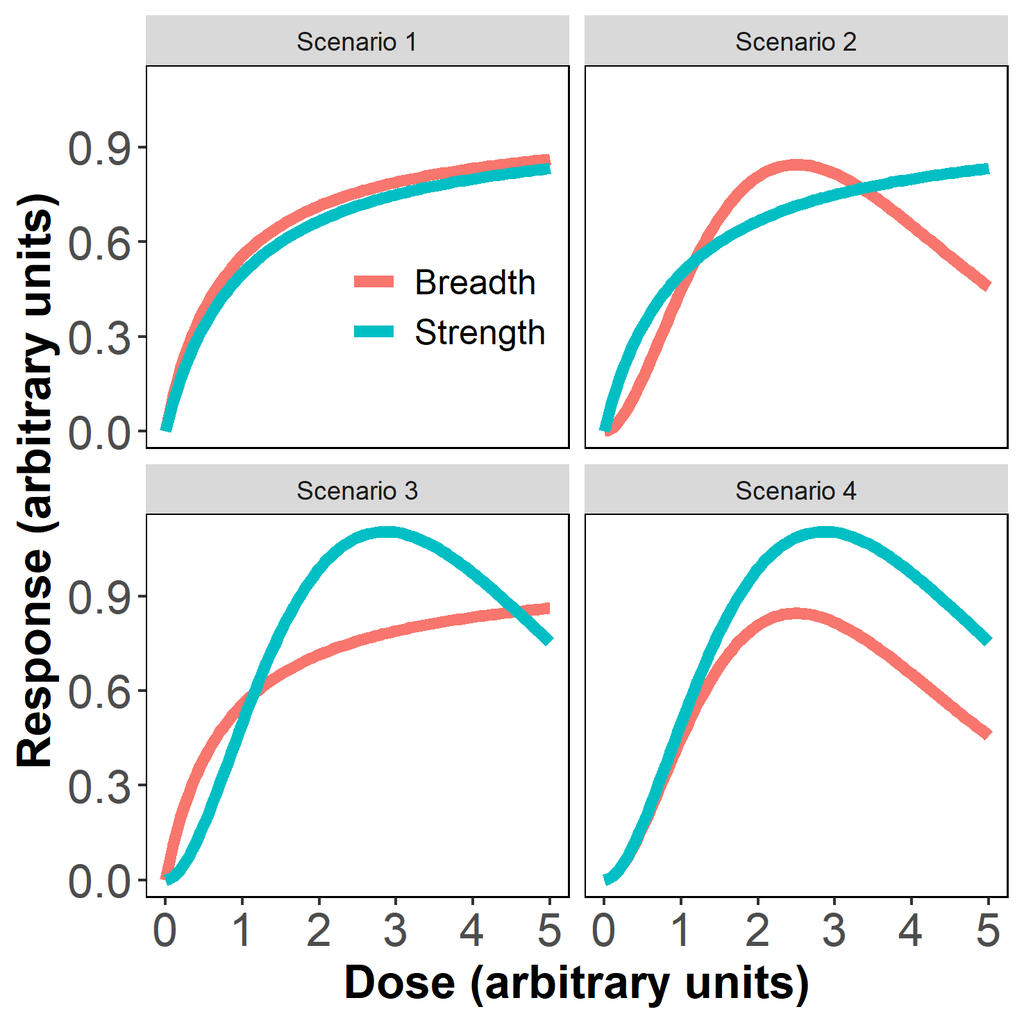

## Modeling the impact of dose

- The overall goal is to determine in more detail, ideally with a mechanistic model, how dose impacts vaccination outcomes.
- Some previous work:
  - [Li & Handel 2014 JTB](http://dx.doi.org/10.1016/j.jtbi.2014.01.008), [Handel et al 2018 PLoS Comp Bio](https://doi.org/10.1371/journal.pcbi.1006505)
  - [Rhodes et al 2016 Vaccine](http://dx.doi.org/10.1016/j.vaccine.2016.10.060), [Rhodes et al 2019 JTB](https://doi.org/10.1016/j.jtbi.2019.01.017)

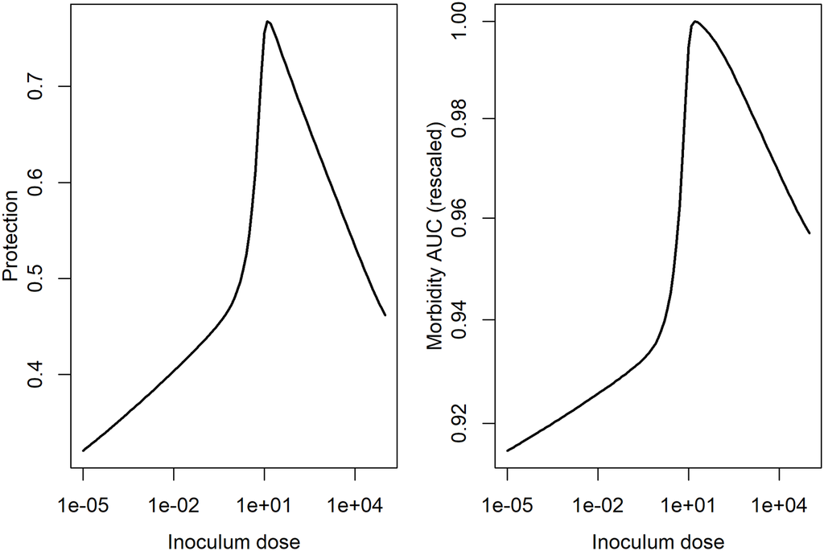

## Current project - study population

- Analysis of antibody responses of individuals who received seasonal flu vaccine.
- Individuals were vaccinated (some repeatedly) during 2014/15 - 2018/19 flu seasons.
- The default vaccine was the trivalent or quadrivalent standard dose (SD, 15µg) Fluzone vaccine.
- Individuals >65 were offered the high-dose (HD, 60µg) trivalent vaccine.

## Current project - analysis

- What is the impact of standard dose (SD) versus high dose (HD) vaccine on immune outcomes?
- Investigate 3 antibody titer (HAI) outcomes:
  - **Fold change** in HAI titer following vaccination.
  - **Seroconversion**, defined as pre-vaccination HAI titer <1:10 (LOD) and post-vaccination titer >= 1:40 OR a >=4-fold increase.
  - **Seroprotection**, defined as post-vaccination HAI >= 1:40.
- Focus on individuals >=65 years.

## Homologous responses, H1N1 HAI ratio

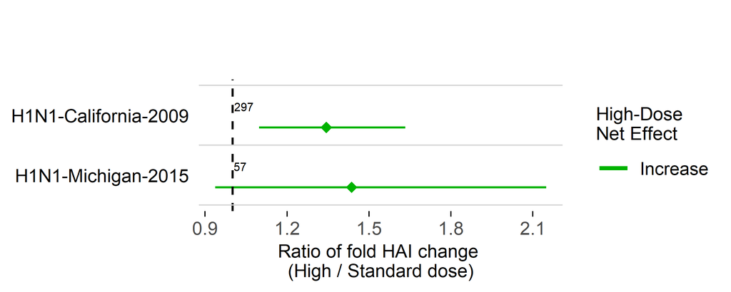

Median and 95% Credible Interval from a univariate analysis

## Homologous responses, H1N1 seroconversion fraction

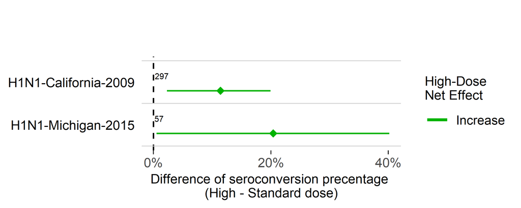

Median and 95% Credible Interval from a univariate analysis

## Homologous responses, H1N1 seroprotection fraction

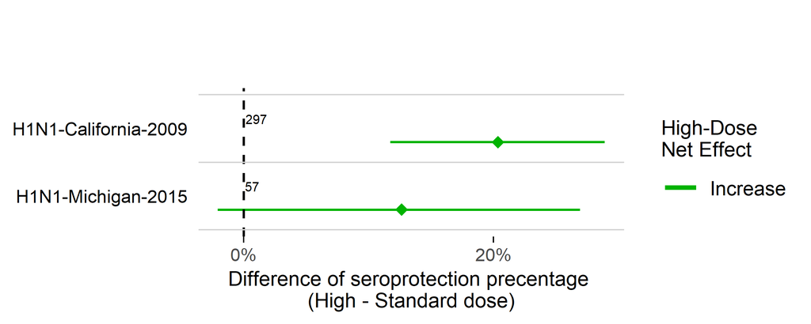

Median and 95% Credible Interval from a univariate analysis

## Homologous responses, H3N2 HAI ratio

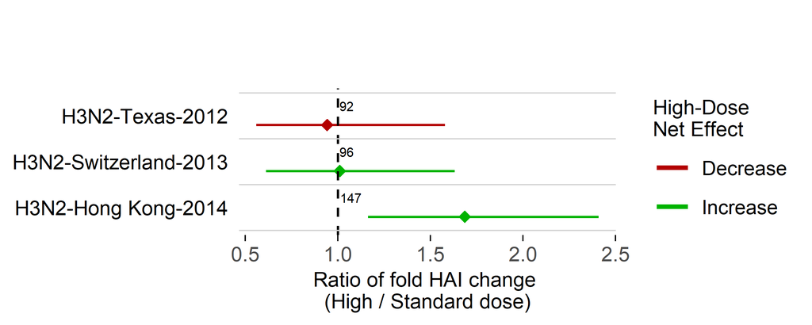

Median and 95% Credible Interval from a univariate analysis

## Homologous responses, H3N2 seroconversion fraction

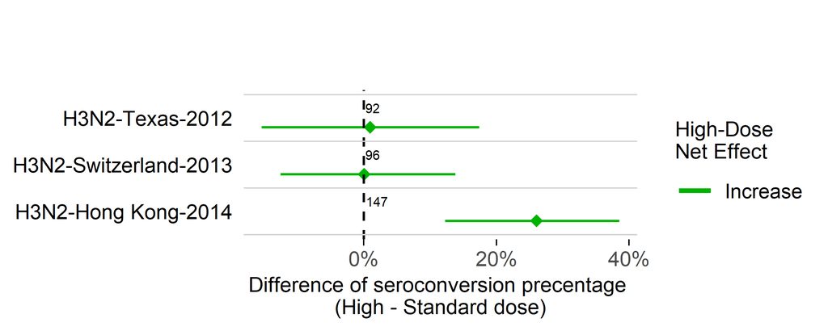

Median and 95% Credible Interval from a univariate analysis

## Homologous responses, H3N2 seroprotection fraction

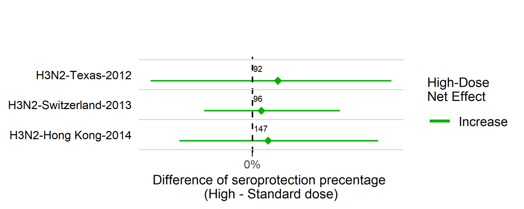

Median and 95% Credible Interval from a univariate analysis

## Homologous responses, B

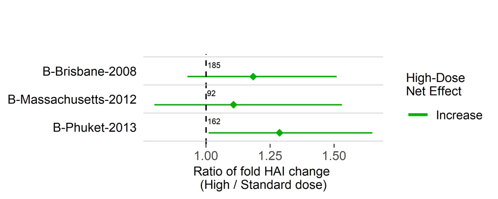

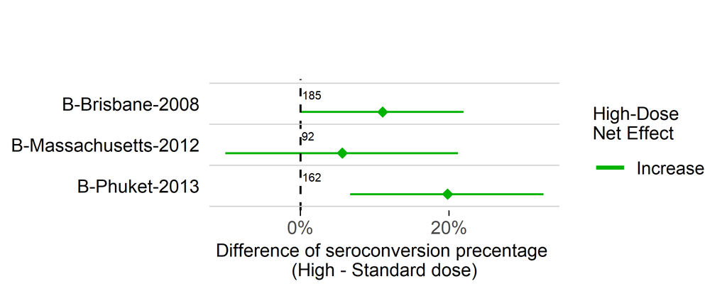

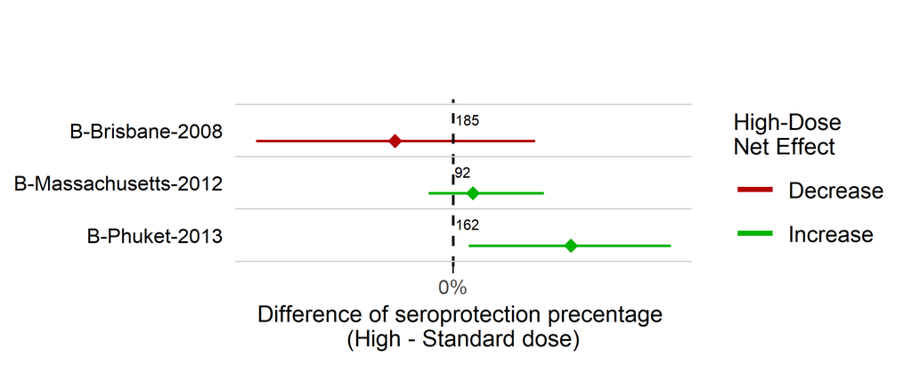

## Homologous responses - multivariate

- Controlling for pre-existing titer, gender, age and race.
- Similar results using a propensity score approach.

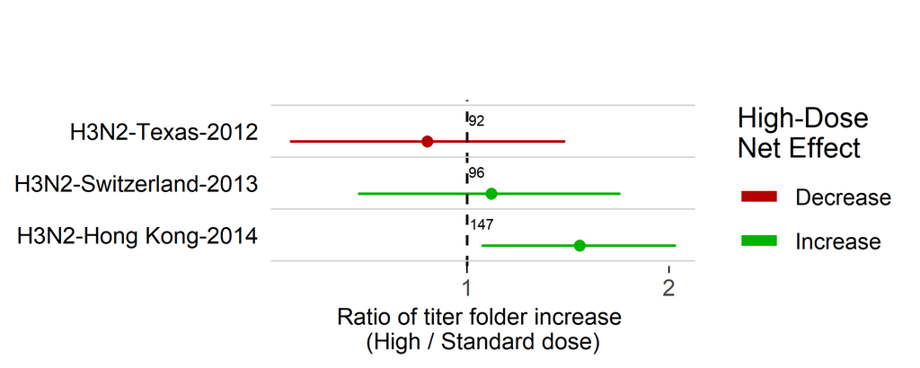

[figure not shown]

## Heterologous responses - multivariate

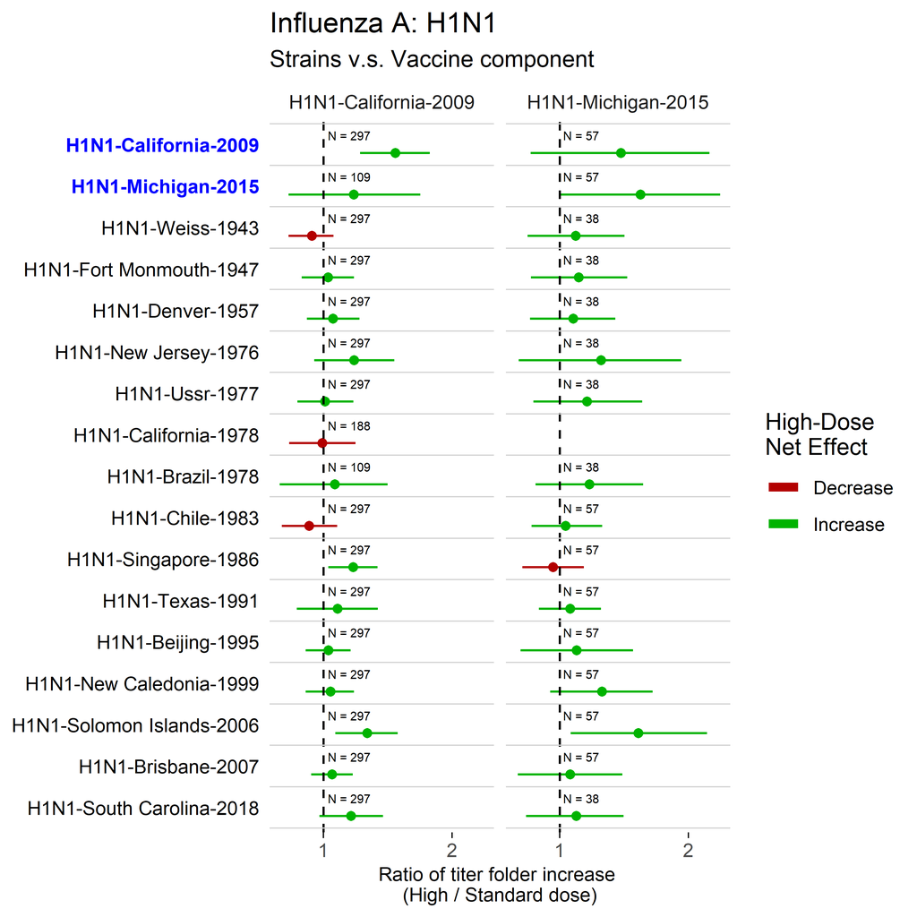

## Heterologous responses - multivariate

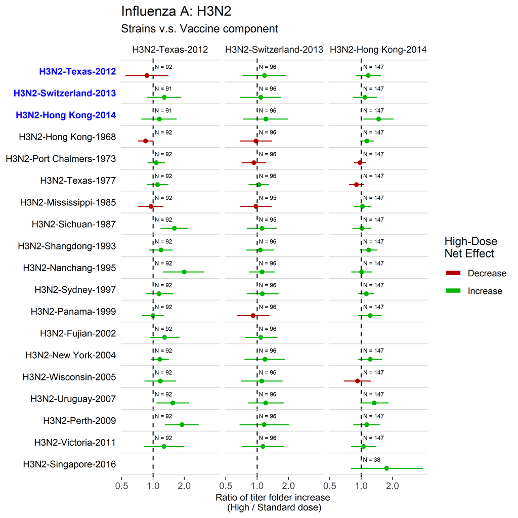

## Heterologous responses - by gender

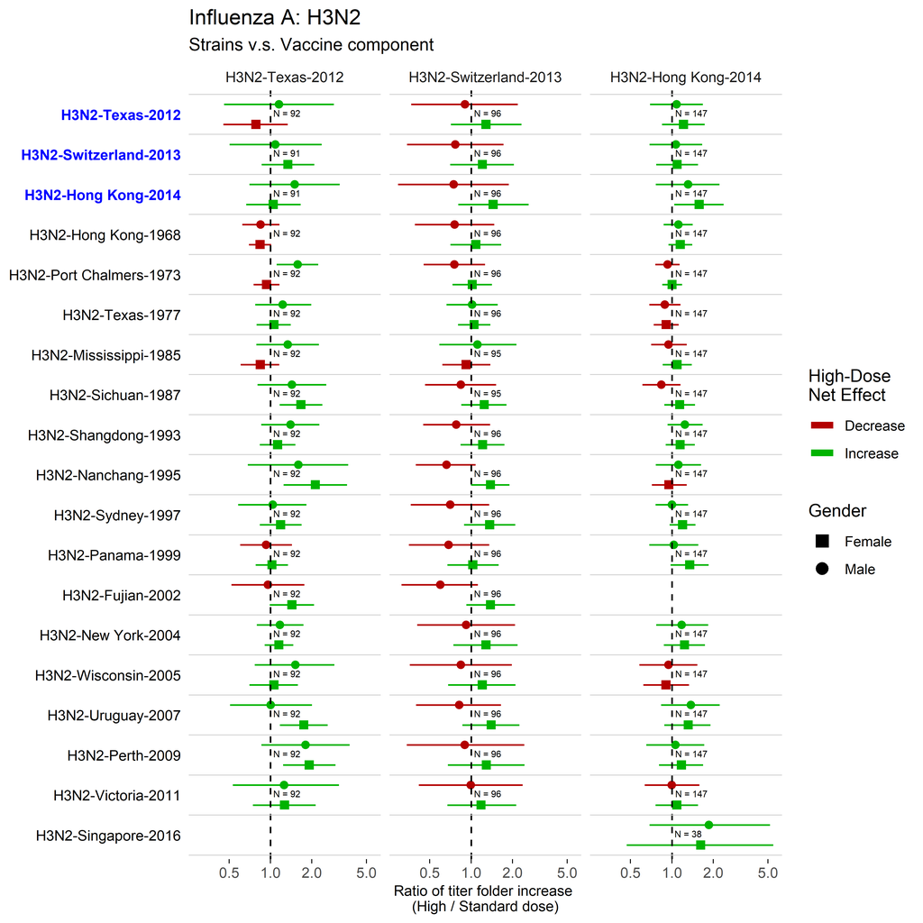

## Summary

- Overall, higher dose seems to better induce antibodies against the vaccine strain, though it depends on strain and year. H3N2 seemed to benefit less by HD.
- There is a tendency for HD to induce better heterologous protection, but the effect is overall small and inconsistent.
- There might be interaction between dose and gender for some vaccine strains.
- This is an exploratory analysis, further investigation/confirmation is needed.

## Thanks!

- Collaborators:
  - Group members especially Yang Ge, Brian McKay
  - CIVIC/CIVR-HPR members, especially Ye Shen, Ted Ross
- Funding: NIH
- Slides: https://www.andreashandel.com/talk/
- Contact: https://www.andreashandel.com/, @andreashandel